# Assignment 8

Ruinan Wang

24/11/2021

## 1. Obstacles to valid scientific inference

### Measurement Distortions: It is a kind of difference between the measured value of a quantity and its true value.

Example: Measure inaccurately the speed a athlete run 100 miles

### Selection bias: Selection bias is the bias introduced by the selection of individuals, groups, or data for analysis in such a way that proper randomization is not achieved, thereby failing to ensure that the sample obtained is representative of the population of interest

Example: When testing if a medicine is effective or not, student candidates become the main subjects.

### Confounding variables: It is a variable that essfects causal relationship measurement between the indepedent variables X and depedent variables Y

Confounding variables (a.k.a. confounders or confounding factors) are a type of extraneous variable that are related to a study’s independent and dependent variables. A variable must meet two conditions to be a confounder:

It must be correlated with the independent variable. This may be a causal relationship, but it does not have to be. It must be causally related to the dependent variable.

Example: You find that babies born to mothers who smoked during their pregnancies weigh significantly less than those born to non-smoking mothers, but without thinking the subject are also likely to engage in other unhealthy behaviors, which is the confounding variables.

### 2 An unpaired t test

```r
t_test_function <- function(data,val_col,group_col, var_equal){
  data <- data%>%
    group_by(!!sym(group_col))%>%
    summarize(avg=mean(!!sym(val_col)),num = n(), sd = sd(!!sym(val_col)))

  n1 = data$num[1]
  n2 = data$num[2]
  mean1 = data$avg[1]
  mean2 = data$avg[2]
  sd1 = data$sd[1]
  sd2 = data$sd[2]
if (var_equal == FALSE){
  t_statistic <- (mean1-mean2)/sqrt(sd1^2/n1+sd2^2/n2)
  dof <- (sd1^2/n1+sd2^2/n2)^2/((sd1^2/n1)^2/(n1-1)+(sd2^2/n2)^2/(n2-1))
  p_value <- 2*(1-pt(abs(t_statistic),df=dof))
}
  else{
  dof <- n1+n2-2
  sd_combined <- sqrt(((n1-1)*sd1^2+(n2-1)*sd2^2)/(dof))
  t_statistic <- (mean1-mean2)/(sd_combined*sqrt(1/n1+1/n2))
  p_value <- 2*(1-pt(abs(t_statistic),df=dof))
  effect_size <- (mean1-mean2)/sd_combined
}
  return(data.frame(t_statistic,dof,p_value))
}

library(palmerpenguins)
peng_AC<-penguins%>%
drop_na(species,body_mass_g)%>%
filter(species!="Gentoo")

t_test_function(data=peng_AC,val_col="body_mass_g",group_col="species", var_equal = FALSE)
```

```
##   t_statistic      dof   p_value
## 1  -0.5430902 152.4548 0.5878608
```

```r
t.test(body_mass_g~species, data = peng_AC, var.equal=FALSE)
```

```
##
##  Welch Two Sample t-test
##
## data:  body_mass_g by species
## t = -0.54309, df = 152.45, p-value = 0.5879
## alternative hypothesis: true difference in means between group Adelie and group Chinstrap is not equal to 0
## 95 percent confidence interval:
##  -150.38481   85.53284
## sample estimates:
##    mean in group Adelie mean in group Chinstrap
##                3700.662                3733.088
```

```r
t_test_function(data=peng_AC,val_col="body_mass_g",group_col="species", var_equal = TRUE)
```

```
##   t_statistic dof   p_value
## 1  -0.5080869 217 0.6119085
```

```r
t.test(body_mass_g~species, data = peng_AC, var.equal=TRUE)
```

```
##
##  Two Sample t-test
##
## data:  body_mass_g by species
## t = -0.50809, df = 217, p-value = 0.6119
## alternative hypothesis: true difference in means between group Adelie and group Chinstrap is not equal to 0
## 95 percent confidence interval:
##  -158.21193   93.35996
## sample estimates:
##    mean in group Adelie mean in group Chinstrap
##                3700.662                3733.088
```

## 3.Statistical hypothesis testing

```
  1.Null hypothesis: The null hypothesis is our default position typically declaring an absence of an interesting phenomena.
  2. Alternative hypothesis: The alternative hypothesis is the of something interesting difference we’d like to demonstrate.
  3. Test statistic: it's used for determining if the null hypothesis should be rejected or not. The value for test statistics can be compared with the expected results under the null hypothesis.
  4. Type 1 error: it refers to that wrongly rejects the null hypothesis but the null hypothesis is true.
  5. Type 2 error: it refers to that we fail to reject the null hypothesis but the null hypothesis is wrong.
  6. The test size: it is the probability of Type I error under the null hypothesis.
  7. The power of test: it is the probability of ( 1- Type II error under the alternative hypothesis).
  8. The significance level: permitting the probability of making the type 1 error. can be taken as the risk which can be undertaken or the critical level.
  9. P value: The probability of the statistics appearing the extreme value.
  10. Effect size: The effect size is a measure for quantifying the magnitude of the observed phenomena
```

#### Is the p-value the probability that the null hypothesis is true?

P value is the probability of misjudge H0 as false under rejecting H0. If the p value is smaller, which indicates the the probability of misjudgment to H0 is smaller, and you are more confident to reject H0 and accept H1.

p-value = P(H0 is true | rejecting H0)

#### If I conduct a statistical hypothesis test, and my p-value exceeds the significance level, do I have good evidence that the null hypothesis is true?

We still can not say the null hypothesis is true, we just can say we have no enough evidence to reject the null hypothesis.

## 4 Investigating test size for an unpaired Student’s t-test

The significance level wasn’t supplied as an argument. Is this a problem?  
If the significance level (confidence level) is not specified, the default is conf.level = 0.95

```r
num_trials<-1000
sample_size<-30
mu_0<-1
mu_1<-1
sigma_0<-3
sigma_1<-3
alpha<-0.05
set.seed(0) # set random seed for reproducibility
single_alpha_test_size_simulation_df<-data.frame(trial=seq(num_trials))%>%
  mutate(sample_0=map(.x=trial,.f=~rnorm(n=sample_size,mean=mu_0,sd=sigma_0)), sample_1=map(.x=trial,.f=~rnorm(n=sample_size,mean=mu_1,sd=sigma_1)))%>%
  # generate random Gaussian samples
  mutate(p_value=pmap(.l=list(trial,sample_0,sample_1), .f=~t.test(..2,..3,var.equal = TRUE)$p.value))%>%
# generate p values
  mutate(type_1_error=p_value<alpha)
single_alpha_test_size_simulation_df%>%
  pull(type_1_error)%>%
  mean() # estimate of coverage probability
```

```
## [1] 0.055
```

```r
num_trials_per_alpha<-100
sample_size<- 30
alpha_min<-0.0025
alpha_max<-0.25
alpha_inc<-0.0025
set.seed(0)
test_size_per_alpha_simulation_df<- crossing(trial=seq(num_trials_per_alpha),alpha=seq(alpha_min,alpha_max,alpha_inc))%>%
  mutate(sample_0=map(.x=trial,.f=~rnorm(n=sample_size,mean=mu_0,sd=sigma_0)), sample_1=map(.x=trial,.f=~rnorm(n=sample_size,mean=mu_1,sd=sigma_1)))%>%
  mutate(p_value=pmap(.l=list(trial,sample_0,sample_1), .f = ~t.test(..2,..3,var.equal=TRUE)$p.value)) %>%
  mutate(type_1_error=p_value<alpha)%>%
  group_by(alpha)%>%
    summarize(test_size = mean(type_1_error))
head(test_size_per_alpha_simulation_df)
```

```
## # A tibble: 6 x 2
##    alpha test_size
##    <dbl>     <dbl>
## 1 0.0025      0.01
## 2 0.005       0
## 3 0.0075      0.02
## 4 0.01        0.01
## 5 0.0125      0.02
## 6 0.015       0
```

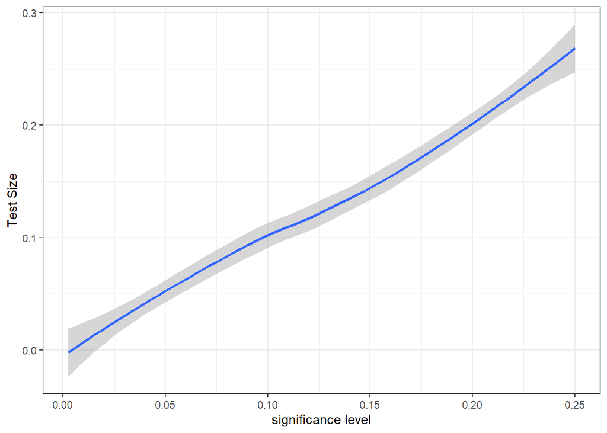

```r
test_size_per_alpha_simulation_df%>%
  ggplot(aes(x=alpha,y=test_size))+geom_smooth()+xlab("significance level")+ylab("Test Size")+theme_bw()
```

### 5 The power of an unpaired t-test

```r
num_trials<-100
n_0<-30
n_1<-30
mu_0<-3
mu_1<-4
sigma_0<-2
sigma_1<-2
alpha<-0.05
set.seed(0) # set random seed for reproducibility
data.frame(trial=seq(num_trials))%>%
  mutate(sample_0=map(.x=trial,.f=~rnorm(n=n_0,mean=mu_0,sd=sigma_0)), sample_1=map(.x=trial,.f=~rnorm(n=n_1,mean=mu_1,sd=sigma_1)))%>%
  # generate random Gaussian samples
  mutate(p_value=pmap(.l=list(trial,sample_0,sample_1), .f=~t.test(..2,..3,var.equal = TRUE)$p.value))%>%
  # generate p values
  mutate(reject_null=p_value<alpha)%>%
  pull(reject_null)%>%
  mean() # estimate of coverage probability
```

```
## [1] 0.45
```

```r
num_trials_per_alpha<-100
sample_size<- 30
alpha_min<-0.0025
alpha_max<-0.25
alpha_inc<-0.0025
set.seed(0)
test_power_per_alpha_simulation_df<- crossing(trial=seq(num_trials_per_alpha),alpha=seq(alpha_min,alpha_max,alpha_inc))%>%
  mutate(sample_0=map(.x=trial,.f=~rnorm(n=sample_size,mean=mu_0,sd=sigma_0)), sample_1=map(.x=trial,.f=~rnorm(n=sample_size,mean=mu_1,sd=sigma_1)))%>%
  mutate(p_value=pmap(.l=list(trial,sample_0,sample_1), .f = ~t.test(..2,..3, var.equal=TRUE)$p.value))%>%
  mutate(reject_null=p_value<alpha)%>%
  group_by(alpha)%>%
    summarize(test_power = mean(reject_null))
head(test_power_per_alpha_simulation_df)
```

```
## # A tibble: 6 x 2
##    alpha test_power
##    <dbl>      <dbl>
## 1 0.0025       0.07
## 2 0.005        0.16
## 3 0.0075       0.17
## 4 0.01         0.16
## 5 0.0125       0.2
## 6 0.015        0.27
```

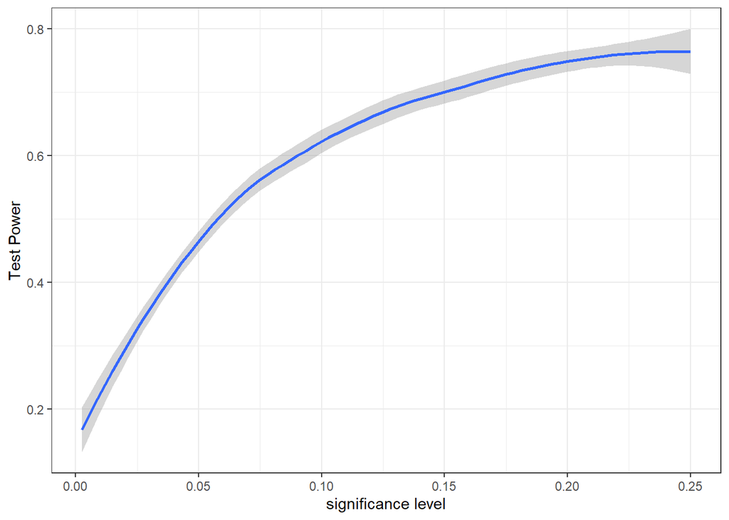

```r
test_power_per_alpha_simulation_df%>%
  ggplot(aes(x=alpha,y=test_power))+geom_smooth()+xlab("significance level")+ylab("Test Power")+theme_bw()
```

```r
num_trials_per_mean<-100
sample_size<- 30
mean_min<-0
mean_inc<-0.1
mean_max<-5
sigma<- 2
alpha<-0.05
mu_0<-3
set.seed(0)
test_power_per_mean_simulation_df<- crossing(trial=seq(num_trials_per_mean),difference_mean=seq(mean_min,mean_max,mean_inc))%>%
  mutate(sample_0=map(.x=trial,.f=~rnorm(n=sample_size,mean=mu_0,sd=sigma)), sample_1=map2(.x=trial, .y=difference_mean, .f=~rnorm(n=sample_size,mean = mu_0 + .y, sd = sigma)))%>%
  mutate(p_value=pmap(.l=list(trial,sample_0,sample_1), .f = ~t.test(..2,..3,var.equal=TRUE)$p.value))%>%
  mutate(reject_null=p_value<alpha)%>%
  group_by(difference_mean)%>%
    summarize(test_power = mean(reject_null))
head(test_power_per_mean_simulation_df)
```

```
## # A tibble: 6 x 2
##   difference_mean test_power
##             <dbl>      <dbl>
## 1             0         0.05
## 2             0.1       0.07
## 3             0.2       0.03
## 4             0.3       0.13
## 5             0.4       0.09
## 6             0.5       0.18
```

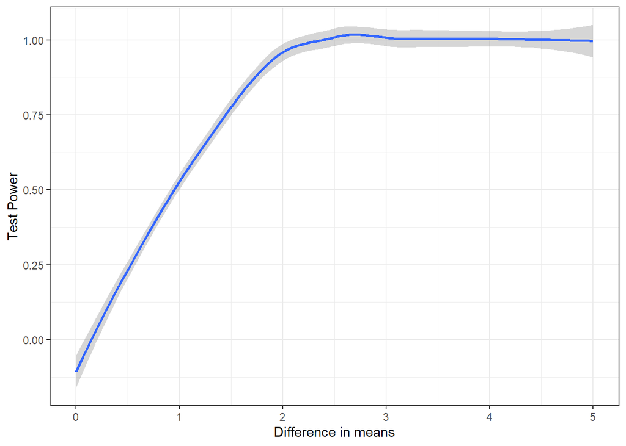

```r
test_power_per_mean_simulation_df%>%
  ggplot(aes(x=difference_mean,y=test_power))+geom_smooth()+xlab("Difference in means")+ylab("Test Power")+theme_bw()
```

```r
num_trials_per_sd<-100
sample_size<- 30
sd_min<-0.1
sd_inc<-0.01
sd_max<-3
mu_0<- 3
mu_1<- 4
alpha<-0.05
set.seed(0)
test_power_per_sd_simulation_df<- crossing(trial=seq(num_trials_per_mean),sd=seq(sd_min,sd_max,sd_inc))%>%
  mutate(sample_0=pmap(.l=list(trial,sd),.f=~rnorm(n=sample_size,mean=mu_0,sd=..2)), sample_1=pmap(.l=list(trial,sd),.f=~rnorm(n=sample_size,mean=mu_1,sd=..2)))%>%
  mutate(p_value=pmap(.l=list(trial,sample_0,sample_1,sd), .f = ~t.test(..2,..3,var.equal=TRUE)$p.value))%>%
  mutate(reject_null=p_value<alpha)%>%
  group_by(sd)%>%
    summarize(test_power = mean(reject_null))
head(test_power_per_sd_simulation_df)
```

```
## # A tibble: 6 x 2
##      sd test_power
##   <dbl>      <dbl>
## 1  0.1           1
## 2  0.11          1
## 3  0.12          1
## 4  0.13          1
## 5  0.14          1
## 6  0.15          1
```

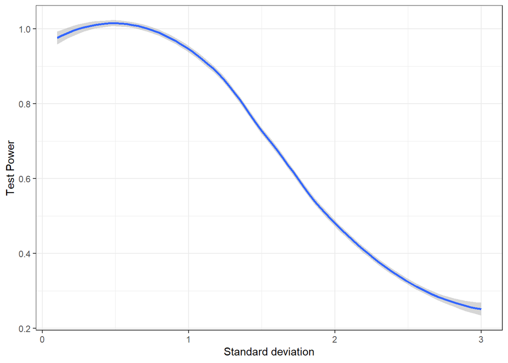

```r
test_power_per_sd_simulation_df%>%
  ggplot(aes(x=sd,y=test_power))+geom_smooth()+xlab("Standard deviation")+ylab("Test Power")+theme_bw()
```

```r
num_trials_per_sample_size<-100
sample_size_min<- 5
sample_size_max<-300
sample_size_inc<-5
sd<-2
mu_0<-3
mu_1<-4
alpha<-0.05
set.seed(0)
test_power_per_sample_size_df<- crossing(trial=seq(num_trials_per_mean),sample_size=seq(sample_size_min,sample_size_max,sample_size_inc))%>%
  mutate(sample_0=pmap(.l=list(trial,sample_size),.f=~rnorm(n=..2,mean=mu_0,sd=sd)), sample_1=pmap(.l=list(trial,sample_size),.f=~rnorm(n=..2,mean=mu_1,sd=sd)))%>%
  mutate(p_value=pmap(.l=list(trial,sample_0,sample_1,sample_size), .f = ~t.test(..2,..3,var.equal=TRUE)$p.value))%>%
  mutate(reject_null=p_value<alpha)%>%
  group_by(sample_size)%>%
    summarize(test_power = mean(reject_null))
head(test_power_per_sample_size_df)
```

```
## # A tibble: 6 x 2
##   sample_size test_power
##         <dbl>      <dbl>
## 1           5       0.13
## 2          10       0.19
## 3          15       0.27
## 4          20       0.28
## 5          25       0.34
## 6          30       0.52
```

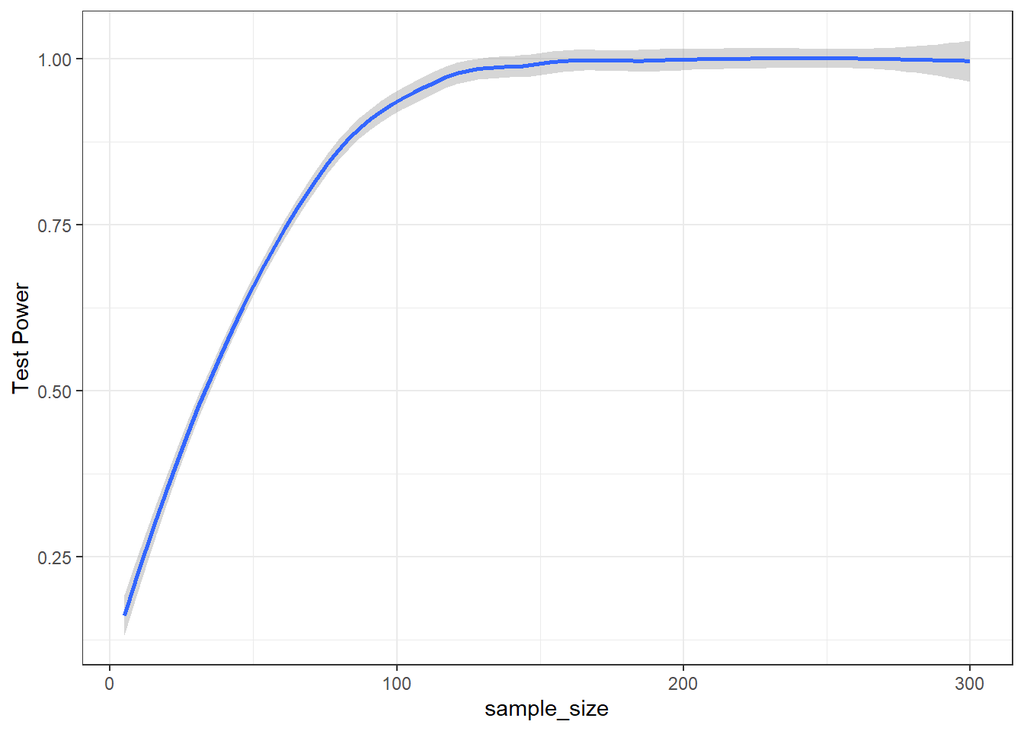

```r
test_power_per_sample_size_df%>%
  ggplot(aes(x=sample_size,y=test_power))+geom_smooth()+xlab("sample_size")+ylab("Test Power")+theme_bw()
```

## 6. Comparing the paired and unpaired t-tests (Optional)

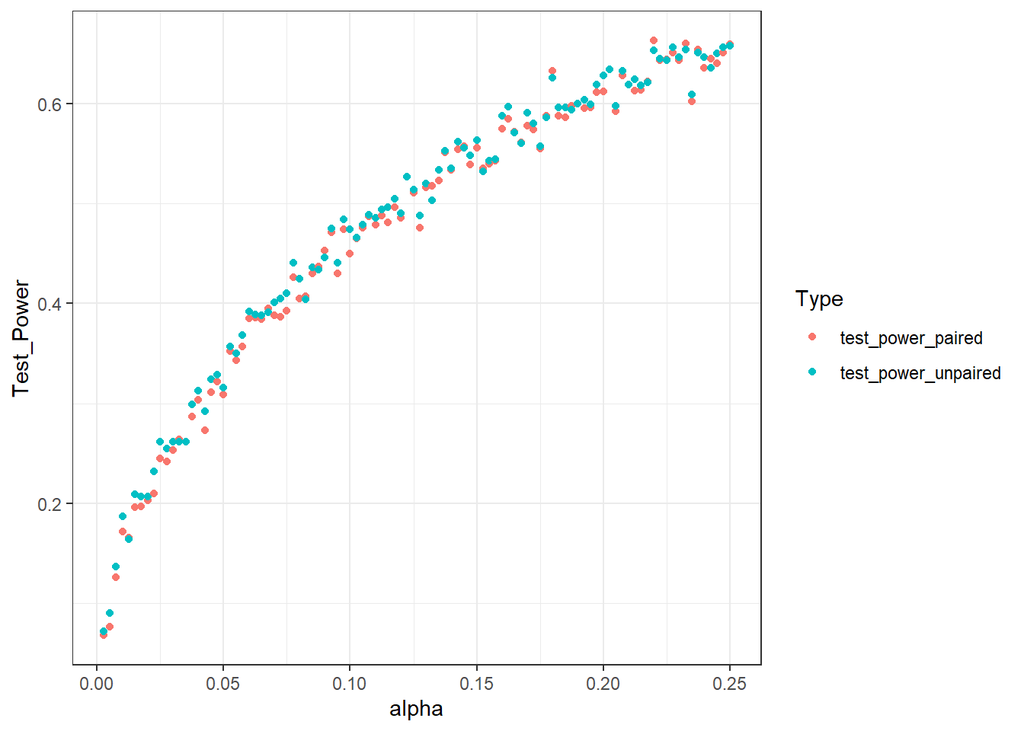

```r
num_trials<-1000
sample_size<-30
mu_x<-3
mu_z<-1
sigma_x<-2
sigma_z<-2
alpha<-0.05

mu_y <- mu_x+mu_z
sigma_y <- sqrt(sigma_x^2+sigma_z^2)

alpha_min<-0.0025
alpha_max<-0.25
alpha_inc<-0.0025
set.seed(0)
test_power_per_alpha_simulation_df <- crossing(trial = seq(num_trials),
                                               alpha=seq(alpha_min, alpha_max, alpha_inc))%>%
  mutate(sample_X = pmap(.l=list(trial,alpha),
                         .f = ~rnorm(sample_size,mu_x,sd=sigma_x)),
         sample_Y = pmap(.l=list(trial,alpha),
                         .f=~rnorm(sample_size,mu_y,sd=sigma_y)))%>%
  mutate(p_value_paired = pmap_dbl(.l=list(trial,sample_X,sample_Y,alpha),
                               .f= ~t.test(..2,..3,paired=TRUE)$p.value))%>%
  mutate(p_value_unpaired = pmap_dbl(.l =list(trial,sample_X,sample_Y,alpha),
                                 .f = ~t.test(..2,..3, paired=FALSE)$p.value))%>%
  mutate(reject_null_paired = p_value_paired < alpha)%>%
  mutate(reject_null_unpaired = p_value_unpaired < alpha)%>%
  group_by(alpha)%>%
  summarize(test_power_paired=mean(reject_null_paired),
            test_power_unpaired=mean(reject_null_unpaired))

test_power_per_alpha_simulation_df <- test_power_per_alpha_simulation_df%>%
   pivot_longer(cols=c(test_power_paired,test_power_unpaired),names_to = "Type", values_to = "Test_Power")

ggplot(data=test_power_per_alpha_simulation_df,aes(x=alpha,y=Test_Power, color = Type, linetype = Type)) + geom_point() + theme_bw()
```

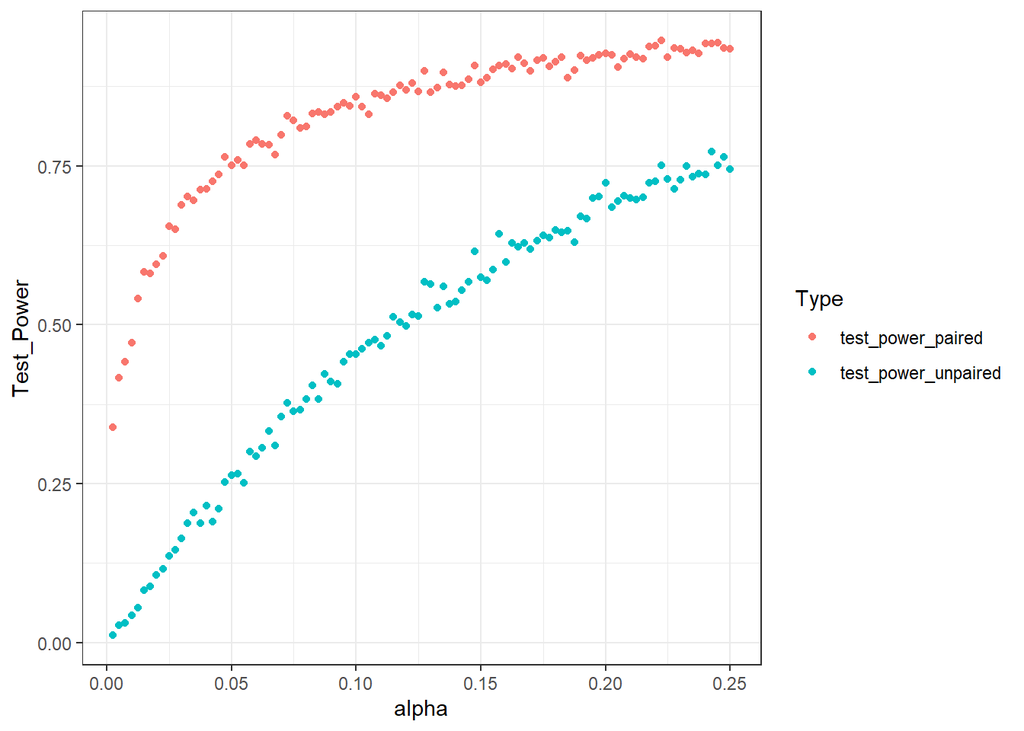

```r
test_power_per_alpha_simulation_df2 <- crossing(trial = seq(num_trials),
                                               alpha=seq(alpha_min, alpha_max, alpha_inc))%>%
  mutate(sample_X = pmap(.l=list(trial,alpha),
                         .f = ~rnorm(sample_size,mu_x,sd=sigma_x)),
         sample_Z = pmap(.l=list(trial,alpha),
                         .f=~rnorm(sample_size,mu_z,sd=sigma_z)))%>%
  mutate(sample_Y = pmap(.l = list(sample_X,sample_Z),
                         .f = ~(..1+..2)))%>%
  mutate(p_value_paired = pmap_dbl(.l=list(trial,sample_X,sample_Y,alpha),
                               .f= ~t.test(..2,..3, paired=TRUE)$p.value))%>%
  mutate(p_value_unpaired = pmap_dbl(.l =list(trial,sample_X,sample_Y,alpha),
                                 .f = ~t.test(..2,..3, paired=FALSE)$p.value))%>%
  mutate(reject_null_paired = p_value_paired < alpha)%>%
  mutate(reject_null_unpaired = p_value_unpaired < alpha)%>%
  group_by(alpha)%>%
  summarize(test_power_paired=mean(reject_null_paired),
            test_power_unpaired=mean(reject_null_unpaired))

test_power_per_alpha_simulation_df2 <- test_power_per_alpha_simulation_df2%>%
  pivot_longer(cols=c(test_power_paired,test_power_unpaired),names_to = "Type", values_to = "Test_Power")
ggplot(data=test_power_per_alpha_simulation_df2,aes(x=alpha,y=Test_Power,color =Type,linetype= Type)) + geom_point() + theme_bw()
```

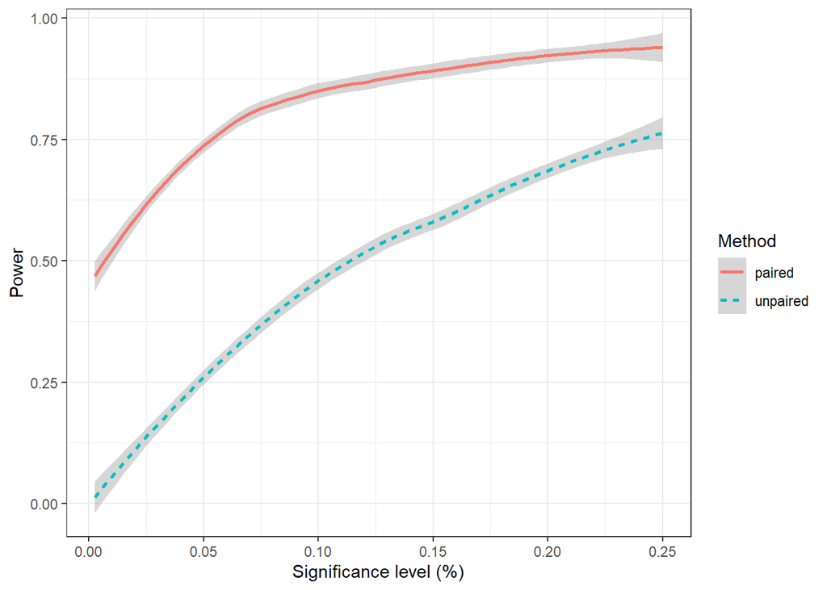

```r
num_trials_per_scenario<-100
n<-30
mu_X<-3
mu_Z<-1
sigma_X<-2
sigma_Z<-2
alpha_min<-0.0025
alpha_max<-0.25
alpha_inc<-0.0025
set.seed(0) # set random seed for reproducibility
crossing(trial=seq(num_trials_per_scenario), alpha=seq(alpha_min,alpha_max,alpha_inc))%>%
  mutate(sample_X=map(.x=trial,.f=~rnorm(n=n,mean=mu_X,sd=sigma_X)),
         sample_Z=map(.x=trial,.f=~rnorm(n=n,mean=mu_Z,sd=sigma_Z)))%>%
  mutate(sample_Y=pmap(.l=list(sample_X,sample_Z),.f=~(..1+..2)))%>% # generate random Gaussian samples
  mutate(p_value_paired=pmap_dbl(.l=list(sample_X,sample_Y),
                                 .f=~t.test(..1,..2,paired=TRUE)$p.value),
         p_value_unpaired=pmap_dbl(.l=list(sample_X,sample_Y),
                                   .f=~t.test(..1,..2,paired=FALSE)$p.value))%>%
  # generate p values
  rename(paired=p_value_paired,unpaired=p_value_unpaired)%>%
  pivot_longer(cols=c(paired,unpaired),
               names_to="Method",values_to = "p_value")%>%
  mutate(reject_null=p_value<alpha)%>%
  group_by(alpha,Method)%>%
  summarise(statistical_power=mean(reject_null))%>%
  ggplot(aes(x=alpha,y=statistical_power,color=Method,linetype=Method))+
  geom_smooth()+xlab("Significance level (%)")+ylab("Power")+
  theme_bw()
```

## 7. A chi-squared test of population variance (Optional)

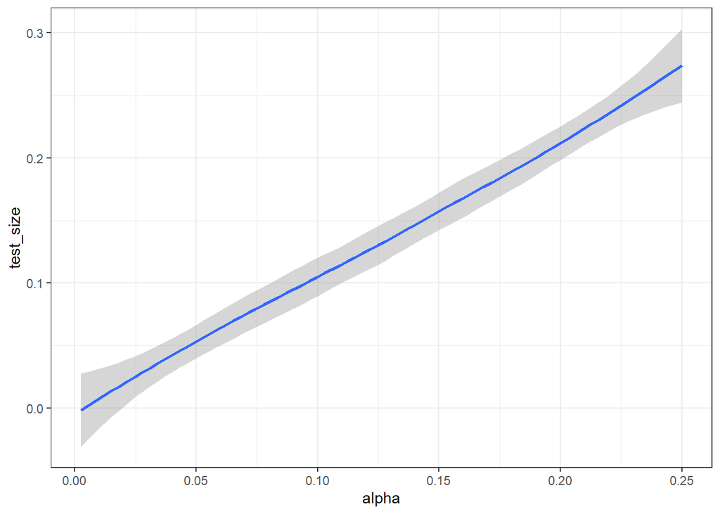

```r
chi_square_test_one_sample_var <- function (sample, sigma_square_null){
  sample<- sample[!is.na(sample)]
  n <- length(sample)
  chi_squared_statistic <- (n-1)*var(sample)/sigma_square_null
  p_value <- 2*min(pchisq(chi_squared_statistic,df=n-1),
                   1-pchisq(chi_squared_statistic,df=n-1))
  return(p_value)
}

alpha_min<-0.0025
alpha_max<-0.25
alpha_inc<-0.0025
set.seed(0)
num_trials_per_alpha<-100
sample_size<- 30
sd <- 3
var_null <- 9
mu <- 1
test_size_per_alpha_variance_simulation_df <- crossing(trial = seq(num_trials_per_alpha), alpha = seq(alpha_min,alpha_max,alpha_inc))%>%
  mutate(sample = map(.x=trial, .f = ~rnorm(sample_size,mu,sd)))%>%
  mutate(p_value = pmap(.l=list(trial,sample), .f=~chi_square_test_one_sample_var(..2,var_null)))%>%
  mutate(reject_null = p_value<alpha)%>%
  group_by(alpha)%>%
  summarize(test_size = mean(reject_null))
test_size_per_alpha_variance_simulation_df %>%
  ggplot(aes(x=alpha,y=test_size))+geom_smooth()+theme_bw()
```

```r
bill_adelie <- penguins %>%
  filter(species == "Adelie") %>%
  pull(bill_length_mm)%>%
  na.omit()

mu_0 <- mean(bill_adelie)
alpha <- 0.1
sd <- 3
p_value <- chi_square_test_one_sample_var(bill_adelie,sd^2)
p_value
```

```
## [1] 0.05196711
```